# Part I - ProsperLoan Dataset Exploration and Analysis

## By: Yaji Timothy T.

## Introduction

> The data set that i choose for projecct III is the Prosperloan data. Prosper is a P2P lending platform that allows investors to choose among personal loans to invest in. They do that by considering a number of factors, that has to do with borrower social economic attributes and the performance and the risk for each loan, among others.There are many questions one could ask of this data, but in this project I will focus on investigate the determining factors of loan delinquency from the perspective of borrower attributes and loan characteristics.

> High loan delinquencies could lead to a liquidity problem that causes financial institution to fall and jeopardizing the country’s economy. The principles of good lending state that a loan should not be granted to a borrower until the source of repayment is reasonably certain. [1](https://doi.org/10.3390/jrfm14070320).

> For ease of analysis i will be select just a few variables that i believe have to do with borrower attributes and loan characteristics.

## Preliminary Wrangling

```python
# import all packages and set plots to be embedded inline
import numpy as np
import pandas as pd
import matplotlib.pyplot as plt
import seaborn as sb
%matplotlib inline
# Ignore warning messages
import warnings
warnings.filterwarnings('ignore')
```

### Read In Data

```python
#read data into pandas data frame
df_loan = original_data = pd.read_csv("prosperLoanData.csv")
```

```python
#set display limit to the total number of rows in the data and view 5 sample point of the data
pd.set_option("display.max_rows", len(df_loan))
df_loan.sample(5)
```

|  | ListingKey | ListingNumber | ListingCreationDate | CreditGrade | Term | LoanStatus | ClosedDate | BorrowerAPR | BorrowerRate | LenderYield | ... | LP_ServiceFees | LP_CollectionFees | LP_GrossPrincipalLoss | LP_NetPrincipalLoss | LP_NonPrincipalRecoverypayments | PercentFunded | Recommendations | InvestmentFromFriendsCount | InvestmentFromFriendsAmount | Investors |
| --- | --- | --- | --- | --- | --- | --- | --- | --- | --- | --- | --- | --- | --- | --- | --- | --- | --- | --- | --- | --- | --- |
| 23231 | 9B3A35494621034621A3343 | 602246 | 2012-06-20 17:13:04.623000000 | NaN | 36 | Past Due (91-120 days) | NaN | 0.25259 | 0.2148 | 0.2048 | ... | -27.97 | 0.00 | 0.00 | 0.00 | 0.0 | 1.0 | 0 | 0 | 0.0 | 5 |
| 50163 | 9C583522210012256CBE51D | 518244 | 2011-07-25 18:01:31.173000000 | NaN | 36 | Completed | 2012-04-05 00:00:00 | 0.22362 | 0.1899 | 0.1799 | ... | -50.97 | 0.00 | 0.00 | 0.00 | 0.0 | 1.0 | 1 | 0 | 0.0 | 7 |
| 39288 | 3AE035211826863630DFEEA | 518708 | 2011-07-27 13:32:03.717000000 | NaN | 36 | Current | NaN | 0.20200 | 0.1799 | 0.1699 | ... | -98.36 | 0.00 | 0.00 | 0.00 | 0.0 | 1.0 | 0 | 0 | 0.0 | 2 |
| 31181 | 5B2D3422051003677D1462A | 344378 | 2008-06-04 12:19:31 | D | 36 | Defaulted | 2009-05-07 00:00:00 | 0.37453 | 0.3500 | 0.3400 | ... | -4.85 | -259.43 | 944.53 | 896.64 | 848.0 | 1.0 | 0 | 0 | 0.0 | 13 |
| 73130 | C46235433343563903FF4F2 | 571244 | 2012-03-23 06:59:46.323000000 | NaN | 36 | Completed | 2012-12-31 00:00:00 | 0.35797 | 0.3177 | 0.3077 | ... | -27.42 | 0.00 | 0.00 | 0.00 | 0.0 | 1.0 | 0 | 0 | 0.0 | 99 |

5 rows × 81 columns

### Assess and Clean Data

```python
#look at the shape of the data
df_loan.info()
```

```
<class 'pandas.core.frame.DataFrame'>
RangeIndex: 113937 entries, 0 to 113936
Data columns (total 81 columns):
 #   Column                               Non-Null Count   Dtype
---  ------                               --------------   -----
 0   ListingKey                           113937 non-null  object
 1   ListingNumber                        113937 non-null  int64
 2   ListingCreationDate                  113937 non-null  object
 3   CreditGrade                          28953 non-null   object
 4   Term                                 113937 non-null  int64
 5   LoanStatus                           113937 non-null  object
 6   ClosedDate                           55089 non-null   object
 7   BorrowerAPR                          113912 non-null  float64
 8   BorrowerRate                         113937 non-null  float64
 9   LenderYield                          113937 non-null  float64
```

[output cut: 73 more lines]

The data has 113937 and 81 variables, 3 are of bolean type, 50 are float, 11 are type integer, and 17 are object type.For ease of analysis, i will select 19 variables that i believe have to do with borrower attributes and loan characteristics that align with the scope of our analysis.

- **Make copy of the dataset**

```python
#make a copy of the data
df_loanCopy=df_loan.copy()
```

- **Select the columns of interest**

```python
#created a list of variable to be used in analysis
selected_var=['Term', 'LoanStatus','BorrowerAPR', 'BorrowerRate','ListingCategory (numeric)',
'BorrowerState','Occupation', 'EmploymentStatus','IsBorrowerHomeowner', 'CreditScoreRangeLower',
'CreditScoreRangeUpper','CurrentlyInGroup','OpenRevolvingAccounts','DebtToIncomeRatio',
'IncomeVerifiable','StatedMonthlyIncome', 'LoanOriginalAmount','ListingCreationDate','MonthlyLoanPayment']

#filter filter out the wanted columns of interest
df_loan_selected=df_loanCopy[selected_var]
```

```python
#look at the structure of the selected data
df_loan_selected.info()
```

```
<class 'pandas.core.frame.DataFrame'>
RangeIndex: 113937 entries, 0 to 113936
Data columns (total 19 columns):
 #   Column                     Non-Null Count   Dtype
---  ------                     --------------   -----
 0   Term                       113937 non-null  int64
 1   LoanStatus                 113937 non-null  object
 2   BorrowerAPR                113912 non-null  float64
 3   BorrowerRate               113937 non-null  float64
 4   ListingCategory (numeric)  113937 non-null  int64
 5   BorrowerState              108422 non-null  object
 6   Occupation                 110349 non-null  object
 7   EmploymentStatus           111682 non-null  object
 8   IsBorrowerHomeowner        113937 non-null  bool
 9   CreditScoreRangeLower      113346 non-null  float64
 10  CreditScoreRangeUpper      113346 non-null  float64
 11  CurrentlyInGroup           113937 non-null  bool
 12  OpenRevolvingAccounts      113937 non-null  int64
 13  DebtToIncomeRatio          105383 non-null  float64
 14  IncomeVerifiable           113937 non-null  bool
 15  StatedMonthlyIncome        113937 non-null  float64
 16  LoanOriginalAmount         113937 non-null  int64
 17  ListingCreationDate        113937 non-null  object
 18  MonthlyLoanPayment         113937 non-null  float64
dtypes: bool(3), float64(7), int64(4), object(5)
memory usage: 14.2+ MB
```

- **Check for duplicated row in the data set**

```python
#check for duplicate rows
df_loan_selected.duplicated().sum()
```

```
871
```

There are 871 duplicates rows in the dataset, we have to drop thise row.

```python
#drop the duplicates
df_loan_selected.drop_duplicates(inplace=True);
```

```python
#check if duplicates exist
assert df_loan_selected.duplicated().sum()==0
```

- **Check for null values in each column**

```python
#check null values in each columns
df_loan_selected.isnull().sum()
```

```
Term                            0
LoanStatus                      0
BorrowerAPR                    25
BorrowerRate                    0
ListingCategory (numeric)       0
BorrowerState                5515
Occupation                   3529
EmploymentStatus             2255
IsBorrowerHomeowner             0
CreditScoreRangeLower         591
CreditScoreRangeUpper         591
CurrentlyInGroup                0
OpenRevolvingAccounts           0
DebtToIncomeRatio            8472
IncomeVerifiable                0
StatedMonthlyIncome             0
LoanOriginalAmount              0
ListingCreationDate             0
MonthlyLoanPayment              0
dtype: int64
```

We have we have null values on BorrowerAPR (25),BorrowerState (5515), Occupation (3529), EmploymentStatus (2255), CreditScoreRangeLower (591), CreditScoreRangeUpper (591), and DebtToIncomeRatio (8472).

For all the categorical variables let us fill all the null values with 'Unkown' because we have been told that null values indicate unknown values in the variables description

```python
#fill all missing data categorical data
missing_categorical = df_loan_selected.select_dtypes(include=["object"]).columns.values

df_loan_selected[missing_categorical] = df_loan_selected[missing_categorical].fillna("Unknown")
```

- Test to see if they are still null values

```python
#check null values
df_loan_selected.select_dtypes(exclude=[np.number]).isnull().sum()
```

```
LoanStatus             0
BorrowerState          0
Occupation             0
EmploymentStatus       0
IsBorrowerHomeowner    0
CurrentlyInGroup       0
IncomeVerifiable       0
ListingCreationDate    0
dtype: int64
```

There are no null values in the selected categorical columns show above.

Next we have to handle the missing values in the numeric columns like BorrowerAPR, CreditScoreRangeLower,CreditScoreRangeUpper, and DebtToIncomeRatio

For BorrowerAPR, CreditScoreRangeLower, and CreditScoreRangeUpper let use the most conservative approach which is to drop the missing values rather than fill them with means or mode or median values.

```python
#drop missing values in BorrowerAPR, CreditScoreRangeLower,CreditScoreRangeUpper
df_loan_selected.dropna(subset=["BorrowerAPR","CreditScoreRangeLower","CreditScoreRangeUpper"], inplace=True)
```

```python
#Test to see that values are droped
df_loan_selected[["BorrowerAPR","CreditScoreRangeLower","CreditScoreRangeUpper"]].isnull().sum()
```

```
BorrowerAPR              0
CreditScoreRangeLower    0
CreditScoreRangeUpper    0
dtype: int64
```

We can see that all the null values have been dropped.

- **Handle Missing Values in DebtToIncomeRatio**

Debt-to-income ratio (DTI) is all your monthly debt payments divided by your gross monthly income. This number is one way lenders measure your ability to manage the monthly payments to repay the money you plan to borrow. [For details click here](https://www.consumerfinance.gov/ask-cfpb/what-is-a-debt-to-income-ratio-en-1791/) we have to examine further to see the nature of the null values in this column used in its calculation

```python
# Filter null values in debt to income ratio
df_null = df_loan_selected[df_loan_selected["DebtToIncomeRatio"].isnull()]

#check to see if there any any missing values in MonthlyLoanPayment and StatedMonthlyIncome columns
print('Nulls in MonthlyLoanPayment=', df_null["MonthlyLoanPayment"].isnull().sum(),)
print('Nulls in StatedMonthlyIncome=', df_null["StatedMonthlyIncome"].isnull().sum())

'select only the desire columns with sample size 7'
df_null[['IncomeVerifiable','StatedMonthlyIncome','MonthlyLoanPayment','DebtToIncomeRatio']].sample(7)
```

```
Nulls in MonthlyLoanPayment= 0
Nulls in StatedMonthlyIncome= 0
```

|  | IncomeVerifiable | StatedMonthlyIncome | MonthlyLoanPayment | DebtToIncomeRatio |
| --- | --- | --- | --- | --- |
| 6703 | False | 3333.333333 | 327.34 | NaN |
| 51286 | False | 8083.333333 | 236.05 | NaN |
| 14007 | False | 2666.666667 | 151.99 | NaN |
| 83643 | False | 3166.666667 | 339.27 | NaN |
| 11339 | False | 2083.333333 | 173.71 | NaN |
| 19342 | False | 8166.666667 | 506.42 | NaN |
| 38386 | False | 4416.666667 | 125.60 | NaN |

All of these data points with missing values have a monthly income and monthly loan payment which are variables that are used in computing debt-to-income-ratio. Probably this May have to do with income not being verifiable. let us check to see if all the values under incomeverified column are false

```python
#check to see if all the values under incomeverified column are false
df_null["IncomeVerifiable"].value_counts()
```

```
False    8304
True      162
Name: IncomeVerifiable, dtype: int64
```

```python
##Calculate DebtToIncomeRatio for for all the missing values
df_loan_selected["DebtToIncomeRatio"]= df_loan_selected["DebtToIncomeRatio"].fillna(df_loan_selected["MonthlyLoanPayment"] / (df_loan_selected["StatedMonthlyIncome"] + 1))
```

```python
#check to see if null values still exist in the column
assert (df_loan_selected["DebtToIncomeRatio"].isnull()).sum()==0
```

```python
#Test to see that all the values Null values have been handlled
df_loan_selected.isnull().sum()
```

```
Term                         0
LoanStatus                   0
BorrowerAPR                  0
BorrowerRate                 0
ListingCategory (numeric)    0
BorrowerState                0
Occupation                   0
EmploymentStatus             0
IsBorrowerHomeowner          0
CreditScoreRangeLower        0
CreditScoreRangeUpper        0
CurrentlyInGroup             0
OpenRevolvingAccounts        0
DebtToIncomeRatio            0
IncomeVerifiable             0
StatedMonthlyIncome          0
LoanOriginalAmount           0
ListingCreationDate          0
MonthlyLoanPayment           0
dtype: int64
```

All Missing values have been handdled.

- **Feature Enginering**

Here, we will create new variables (variable of interest), recode variables and change datatypes appropriately.

**LoanStaus**

Our variable of interest Delinquent will be gotten from this variable

```python
#Chech the levels in this variable
df_loan_selected.LoanStatus.value_counts()
```

```
Current                   55730
Completed                 37645
Chargedoff                11944
Defaulted                  4892
Past Due (1-15 days)        800
Past Due (31-60 days)       361
Past Due (61-90 days)       311
Past Due (91-120 days)      304
Past Due (16-30 days)       265
FinalPaymentInProgress      203
Past Due (>120 days)         16
Cancelled                     4
Name: LoanStatus, dtype: int64
```

This is our dependent variable, (Variable of intrest). To simplify the problem, and to retain data, let's classify all "past Due","Chargedoff and "Defaulted" as delinquent, reason can be found [here](https://www.lawinsider.com/dictionary/current-loan#:~:text=Current%20Loan%20means%20an%20Eligible,such%20on%20the%20Loan%20Schedule) and all others (Current", "cancelled","FinalPaymentInProgress", and "completed") as None Delinquent. Let's encode those binary outcomes as 1 and 0, respectively.

```python
# Create variable of interest DelinquentStatus
Non_delinquent=["FinalPaymentInProgress","Cancelled", "Current", "Completed"]
Delinquentloan_list=[]
for row in df_loan_selected.LoanStatus:
        if row in Non_delinquent: Delinquentloan_list. append (0)
        else:Delinquentloan_list.append(1)
# asign the list to values new column
df_loan_selected['DelinquentStatus'] = Delinquentloan_list
```

```python
#Test to see if the values are coded correctly
df_loan_selected[['DelinquentStatus', 'LoanStatus']].sample(15)
```

|  | DelinquentStatus | LoanStatus |
| --- | --- | --- |
| 11404 | 0 | Completed |
| 73855 | 0 | Current |
| 10831 | 0 | Current |
| 70202 | 1 | Chargedoff |
| 84842 | 1 | Chargedoff |
| 113421 | 0 | Current |
| 73436 | 0 | Current |
| 55278 | 0 | Current |
| 99475 | 0 | Completed |
| 78801 | 0 | Completed |
| 112263 | 0 | Completed |
| 87318 | 0 | Completed |
| 99609 | 0 | Completed |
| 10931 | 0 | Current |
| 22815 | 1 | Chargedoff |

From the sample above we can see that the values are coded correctly.

```python
#Drop LoanStatus column
df_loan_selected.drop(columns="LoanStatus", inplace =True)
```

```python
#Comfirm that LoanStatus is dropped from the dataframe
assert ("LoanStatus" in df_loan_selected.columns)==False
```

**Create a new column "CreditScore" based on the classification provided on [Esperian](https://www.experian.com/blogs/ask-experian/infographic-what-are-the-different-scoring-ranges)**

- First, we have to create empty list and name it CrScore_list
- write a for loop functions which we will append and assign values as per the conditition below:

> CreditScoreRangeUpper is less than or equal to 579 asssign it "Poor"

> CreditScoreRangeUpper between 580-669, asign it "Fair"

> CreditScoreRangeUpper between 670-739, asign it "Good"

> CreditScoreRangeUpper between 740-799, asign it "Very Good"

> CreditScoreRangeUpper is from 800 above, asign it "Exceptional"
- Convert list into column of dataframe

```python
#create an empty list
CrScore_list = []
'''
created a loop which will iterate over all the rows in column 'CreditScoreRangeUpper' and assign
values to CrScore_list. We are using if-else function to make the conditons specified above
'''
for row in df_loan_selected["CreditScoreRangeUpper"]:
    if row <= 579:
        CrScore_list.append("Poor")
    elif row <=669:
        CrScore_list.append("Fair")
    elif row <=739:
        CrScore_list.append("Good")
    elif row<=799:
        CrScore_list.append("Very Good")
    else:
        CrScore_list.append("Exceptional")
```

```python
#Converting list into column of dataset and viewing the final dataset
df_loan_selected["CreditScore"]=CrScore_list

# Test to see that the column is created
df_loan_selected.CreditScore.value_counts()
```

```
Good           60604
Fair           20997
Very Good      20384
Poor            5640
Exceptional     4850
Name: CreditScore, dtype: int64
```

```python
# Drop colums CreditScoreRangeLower" and "CreditScoreRangeUpper"
df_loan_selected.drop(columns=["CreditScoreRangeLower","CreditScoreRangeUpper"], inplace=True)

#Check to see that the columns have been dropped?
df_loan_selected.columns
```

```
Index(['Term', 'BorrowerAPR', 'BorrowerRate', 'ListingCategory (numeric)',
       'BorrowerState', 'Occupation', 'EmploymentStatus',
       'IsBorrowerHomeowner', 'CurrentlyInGroup', 'OpenRevolvingAccounts',
       'DebtToIncomeRatio', 'IncomeVerifiable', 'StatedMonthlyIncome',
       'LoanOriginalAmount', 'ListingCreationDate', 'MonthlyLoanPayment',
       'DelinquentStatus', 'CreditScore'],
      dtype='object')
```

**ListingCategory (numeric)**

We have to recode the variable with more descriptive categories as specified in the variable description file and rename it to ListingCategory.

```python
# create a dictionary to hold the values for listing category
category_dict = {0 : 'Not Available', 1 : 'Debt Consolidation', 2 : 'Home Improvement', 3: 'Business',
             4 : 'Personal Loan', 5 : 'Student Use', 6 : 'Auto', 7 : 'Other', 8 : 'Baby&Adoption',
             9 : 'Boat', 10 : 'Cosmetic Procedure', 11 : 'Engagement Ring', 12 : 'Green Loans',
             13 : 'Household Expenses', 14 : 'Large Purchases', 15 : 'Medical/Dental', 16 : 'Motorcycle',
             17 : 'RV', 18 : 'Taxes', 19 : 'Vacation', 20 : 'Wedding Loans'}
# create a new column 'ListingCategory that holds the categories'
df_loan_selected['ListingCategory'] = df_loan_selected['ListingCategory (numeric)'].map(category_dict)
df_loan_selected.drop(['ListingCategory (numeric)'], axis=1, inplace=True)
```

```python
#Test to see that the categories have been change
df_loan_selected.ListingCategory.unique()
```

```
array(['Not Available', 'Home Improvement', 'Motorcycle',
       'Debt Consolidation', 'Other', 'Household Expenses', 'Auto',
       'Medical/Dental', 'Wedding Loans', 'Vacation', 'Business', 'Taxes',
       'Baby&Adoption', 'Personal Loan', 'Engagement Ring',
       'Large Purchases', 'Student Use', 'Boat', 'RV',
       'Cosmetic Procedure', 'Green Loans'], dtype=object)
```

**Change Datatypes**

```python
#check datatypes
df_loan_selected.dtypes
```

```
Term                       int64
BorrowerAPR              float64
BorrowerRate             float64
BorrowerState             object
Occupation                object
EmploymentStatus          object
IsBorrowerHomeowner         bool
CurrentlyInGroup            bool
OpenRevolvingAccounts      int64
DebtToIncomeRatio        float64
IncomeVerifiable            bool
StatedMonthlyIncome      float64
LoanOriginalAmount         int64
ListingCreationDate       object
MonthlyLoanPayment       float64
DelinquentStatus           int64
CreditScore               object
ListingCategory           object
dtype: object
```

We have to change the dataypes as follows:

LoanOriginationDate: Object to Datatime type and CreditScore : Object to categorical(ordinal).

```python
# Convert 'ListingCreationDate' type from str to datetime
df_loan_selected['ListingCreationDate']=pd.to_datetime(df_loan_selected['ListingCreationDate'])

# Extract date information from ListingCreationDate column and
df_loan_selected['Year'] = df_loan_selected['ListingCreationDate'].dt.year
# extracting the quarter from the date time column
df_loan_selected['Quarter'] = pd.PeriodIndex(df_loan_selected["ListingCreationDate"], freq='Q')
# sorting the quarter column
df_loan_selected.sort_values(by=['Quarter'], inplace=True)
#drop listing creeation date
df_loan_selected.drop(['ListingCreationDate'], axis=1, inplace=True)
```

**convert to norminal categorical type**

```python
#Convert CreditScore to ordinal category type
df_loan_selected["CreditScore"]=df_loan_selected["CreditScore"].astype(pd.api.types.CategoricalDtype(categories=['Poor','Fair', 'Good', 'Very Good', 'Exceptional'], ordered=True))
```

```python
# Check datatypes changed properly
print(df_loan_selected.CreditScore.unique())
```

```
['Fair', 'Very Good', 'Poor', 'Exceptional', 'Good']
Categories (5, object): ['Poor' < 'Fair' < 'Good' < 'Very Good' < 'Exceptional']
```

The data types have been changed sucessfull

```python
#Arrange the columns in a more logical order
Df_ProperLoan_Delinquent= df_loan_selected[['Year','Quarter','ListingCategory','LoanOriginalAmount','Term','BorrowerRate','BorrowerAPR','MonthlyLoanPayment','StatedMonthlyIncome',
                                       'IncomeVerifiable','DebtToIncomeRatio','CreditScore','OpenRevolvingAccounts','EmploymentStatus','IsBorrowerHomeowner',
                                       'CurrentlyInGroup','Occupation','BorrowerState','DelinquentStatus']]
```

```python
Df_ProperLoan_Delinquent.sample(5)
```

|  | Year | Quarter | ListingCategory | LoanOriginalAmount | Term | BorrowerRate | BorrowerAPR | MonthlyLoanPayment | StatedMonthlyIncome | IncomeVerifiable | DebtToIncomeRatio | CreditScore | OpenRevolvingAccounts | EmploymentStatus | IsBorrowerHomeowner | CurrentlyInGroup | Occupation | BorrowerState | DelinquentStatus |
| --- | --- | --- | --- | --- | --- | --- | --- | --- | --- | --- | --- | --- | --- | --- | --- | --- | --- | --- | --- |
| 76180 | 2013 | 2013Q3 | Debt Consolidation | 9000 | 36 | 0.2015 | 0.23898 | 335.16 | 3583.333333 | True | 0.53 | Good | 6 | Employed | True | False | Clerical | MO | 0 |
| 28118 | 2014 | 2014Q1 | Debt Consolidation | 5000 | 36 | 0.0874 | 0.11548 | 158.39 | 5083.333333 | True | 0.10 | Good | 5 | Other | True | False | Unknown | IN | 0 |
| 28207 | 2013 | 2013Q2 | Debt Consolidation | 4000 | 60 | 0.2916 | 0.31848 | 127.36 | 2458.333333 | True | 0.29 | Good | 8 | Other | False | False | Other | FL | 1 |
| 41233 | 2012 | 2012Q4 | Debt Consolidation | 9000 | 36 | 0.1774 | 0.21434 | 324.20 | 4916.666667 | True | 0.30 | Good | 13 | Employed | True | False | Accountant/CPA | CA | 0 |
| 15088 | 2007 | 2007Q2 | Not Available | 6500 | 36 | 0.1600 | 0.16717 | 228.52 | 1421.000000 | True | 0.29 | Good | 5 | Not employed | False | True | Other | Unknown | 0 |

```python
# check all the data types
Df_ProperLoan_Delinquent.dtypes
```

```
Year                             int64
Quarter                  period[Q-DEC]
ListingCategory                 object
LoanOriginalAmount               int64
Term                             int64
BorrowerRate                   float64
BorrowerAPR                    float64
MonthlyLoanPayment             float64
StatedMonthlyIncome            float64
IncomeVerifiable                  bool
DebtToIncomeRatio              float64
CreditScore                   category
OpenRevolvingAccounts            int64
EmploymentStatus                object
IsBorrowerHomeowner               bool
CurrentlyInGroup                  bool
Occupation                      object
BorrowerState                   object
DelinquentStatus                 int64
dtype: object
```

- #### Save data to file

```python
# Save data to file for analysis and insights
Df_ProperLoan_Delinquent.to_csv('ProperLoan_Delinquent.csv', index=False)
```

### Data Exploration

```python
# Check the Structure of our dataset
Df_ProperLoan_Delinquent.info()
```

```
<class 'pandas.core.frame.DataFrame'>
Int64Index: 112475 entries, 77655 to 113936
Data columns (total 19 columns):
 #   Column                 Non-Null Count   Dtype
---  ------                 --------------   -----
 0   Year                   112475 non-null  int64
 1   Quarter                112475 non-null  period[Q-DEC]
 2   ListingCategory        112475 non-null  object
 3   LoanOriginalAmount     112475 non-null  int64
 4   Term                   112475 non-null  int64
 5   BorrowerRate           112475 non-null  float64
 6   BorrowerAPR            112475 non-null  float64
 7   MonthlyLoanPayment     112475 non-null  float64
 8   StatedMonthlyIncome    112475 non-null  float64
 9   IncomeVerifiable       112475 non-null  bool
 10  DebtToIncomeRatio      112475 non-null  float64
 11  CreditScore            112475 non-null  category
 12  OpenRevolvingAccounts  112475 non-null  int64
 13  EmploymentStatus       112475 non-null  object
 14  IsBorrowerHomeowner    112475 non-null  bool
 15  CurrentlyInGroup       112475 non-null  bool
 16  Occupation             112475 non-null  object
 17  BorrowerState          112475 non-null  object
 18  DelinquentStatus       112475 non-null  int64
dtypes: bool(3), category(1), float64(5), int64(5), object(4), period[Q-DEC](1)
memory usage: 14.2+ MB
```

# What is the structure of your dataset?

> 'Year', 'Quarter', 'ListingCategory', 'LoanOriginalAmount', 'Term', 'BorrowerRate', 'MonthlyLoanPayment', 'StatedMonthlyIncome', 'IncomeVerifiable', 'DebtToIncomeRatio', 'CreditScore', 'OpenRevolvingAccounts', 'EmploymentStatus', 'IsBorrowerHomeowner', 'CurrentlyInGroup', 'Occupation', 'BorrowerState', 'DelinquentStatus'

### What is/are the main feature(s) of interest in your dataset?

> I'm interested in the Delinquent loans, most especially looking that: DelinquencyStatus and MonthyLoanPayment.

### What features in the dataset do you think will help support your investigation into your feature(s) of interest?

Please note that it is not an exhaustive list of delinquecy loans determinant. Additional features might be required.

> Most of my cleaning efforts and adjustment were on ordering factors levels to make more intuitive sense and replaceing missing valuesfor non-numeric variables with Unkown and possibly dropping null values in numeric variables

## Univariate Exploration

**What is the distribution of DelinquentStatus?**

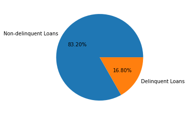

```python
#set base colors
color_base=sb.color_palette()[0]
#Plot a pie chart
plt.pie(Df_ProperLoan_Delinquent.DelinquentStatus.value_counts(), labels=["Non-delinquent Loans", "Delinquent Loans"],colors=None,autopct='%.2f%%');
```

**What is the distribution of MonthlyLoanPayment?**

```python
#Define case-specific function avoid code repetition
def displots(df):
    plt.figure(figsize=[10, 6])
    sb.distplot(df);
    plt.title('Monthly loan payment frequency distribution');
    plt.xlabel('Monthly Payment (USD)');
    plt.ylabel('Count');
    sb.despine(left = False, bottom = False)
```

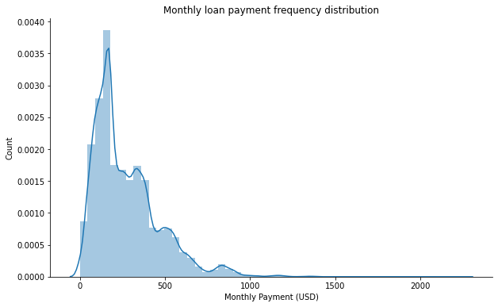

```python
displots(Df_ProperLoan_Delinquent['MonthlyLoanPayment'])
```

**Observation:**

> From the histogram above we can see that the the monthly payment distribution is right skiewed with a long tail.This is an indication that we have outlayers that we have to handle to have a better view of it.

```python
# Check borrowers with stated monthly income greater than $1000
df_outlayer=Df_ProperLoan_Delinquent[Df_ProperLoan_Delinquent['MonthlyLoanPayment']>1000]

# Get percent of borrowers whose stated monthly Loan Payment greater than $1000
outlayer_perc=(Df_ProperLoan_Delinquent['MonthlyLoanPayment']>1000).sum()/float(Df_ProperLoan_Delinquent.shape[0])*100
```

```python
print('The percentage of outlayer points in the data is ','{:.2f}%'.format(outlayer_perc))
```

```
The percentage of outlayer points in the data is  0.39%
```

```python
#Sellect the data
df_loans=Df_ProperLoan_Delinquent[Df_ProperLoan_Delinquent['MonthlyLoanPayment']<=1000]
```

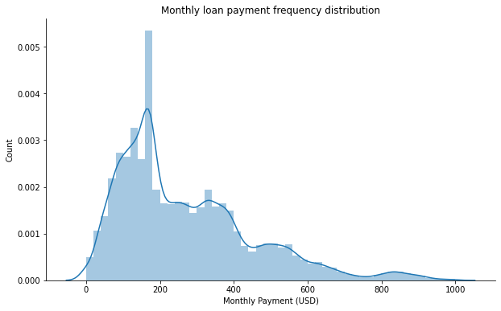

```python
# Plot the distribution
displots(df_loans['MonthlyLoanPayment']);
```

We can now see clearly that Monthly loan payment has a multimodal distribution

**What is the distribution of BorrowerAPR?**

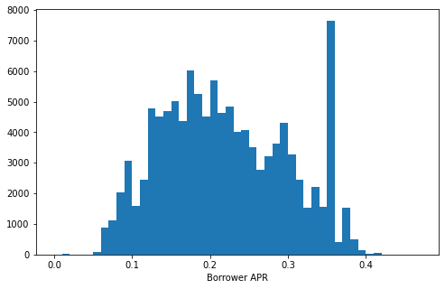

```python
# Set bins for ploting
bins = np.arange(0, Df_ProperLoan_Delinquent.BorrowerAPR.max()+0.05, 0.01)
#Set the figure Size
plt.figure(figsize=[8, 5])
# Plot a histplot
plt.hist(data = Df_ProperLoan_Delinquent, x = 'BorrowerAPR', bins = bins);
plt.xlabel('Borrower APR');
```

**What is the distribution of DebtToIncomeRatio?**

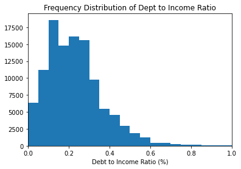

```python
# Plot DebtToIncomeRatio
binsize = 0.05
bins = np.arange(0, Df_ProperLoan_Delinquent['DebtToIncomeRatio'].max()+binsize, binsize)
plt.hist(data = Df_ProperLoan_Delinquent, x = 'DebtToIncomeRatio', bins = bins)
plt.xlabel('Debt to Income Ratio (%)')
plt.title('Frequency Distribution of Dept to Income Ratio')
plt.xlim(0,1);
```

**Observation:**

> It appears from the figure above that the distribution is right skewed with most borrowers who applied for a loan have a debt to income ratio around 15%.

**What is the distribution of CreditScore**

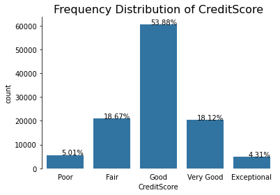

```python
#Define a function for countplot

ax = sb.countplot(data=Df_ProperLoan_Delinquent, x='CreditScore', color=color_base)
plt.title('Frequency Distribution of ''{}'.format('CreditScore'), fontsize=16)
sb.despine(left=False, bottom=True)
ax.grid(False)
ax.tick_params(bottom=False, left=True)
total = float(len(Df_ProperLoan_Delinquent))
'''Add percentage to the bar'''
for p in ax.patches:
    percentage = '{:.2f}%'.format(100 * p.get_height()/total)
    x = p.get_x() + p.get_width()
    y = p.get_height()
    ax.annotate(percentage, (x, y), ha='right', )
   #get the higest bar
patch_h=[patch.get_height() for patch in ax.patches]
#get the highest bar
idx_tal=np.argmax(patch_h);
```

**Observation:**

> From the figure above the credit score are has unimodal distribution with majority of loans coming from borrowers with good credit score.

**What is the distribution of BorrowerRate**

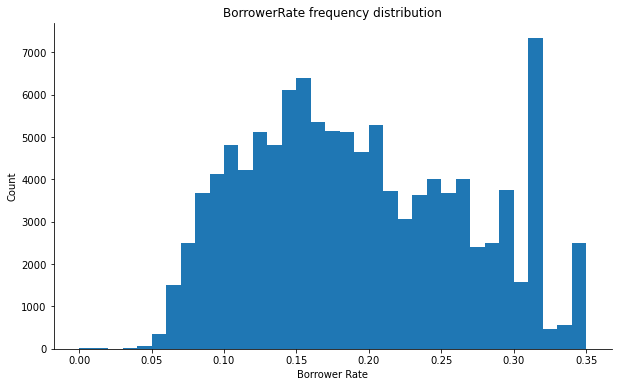

```python
plt.figure(figsize=[10, 6]);
bn = np.arange(0.,Df_ProperLoan_Delinquent['BorrowerRate'].value_counts().index.max(),0.01)
plt.hist(data = Df_ProperLoan_Delinquent, x = 'BorrowerRate', bins = bn)

plt.title('BorrowerRate frequency distribution');
plt.xlabel('Borrower Rate');
plt.ylabel('Count');
sb.despine(left = False, bottom = False);
```

**Observation:**

> From the Plot above, BorrowerRate has multimodal distribution majory of the loans have interest rate below 35% With the highest peak at 0.32

**Term**

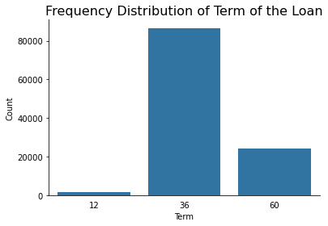

```python
# Plot bar plot for term of loans
cat_order = Df_ProperLoan_Delinquent['ListingCategory'].value_counts().index
ax = sb.countplot(data=Df_ProperLoan_Delinquent, x='Term', color=color_base)
plt.title('Frequency Distribution of Term of the Loan', fontsize=16)
plt.ylabel('Count')
sb.despine(left=False)
ax.tick_params(bottom=False, left=True);
```

**Observation:**

> The Term of the loans in the porfolio has a unimodal distribution. With the most common type of loan Being a 3-year loan (medium term) followed by 5 year loan (Long-Term). The short term loan is very rare.

**How are the Loans in the portfolio distributed in terms of ListingCategory?**

```python
#define a case specific function to avoid repetition of code
def hor_bar_plot():
    cat_order = Df_ProperLoan_Delinquent['ListingCategory'].value_counts().index
    ax = sb.countplot(data=Df_ProperLoan_Delinquent, y='ListingCategory', order=cat_order,color=color_base)
    plt.title('Frequency Distribution of Listing Category', fontsize=16)
    plt.ylabel(None)
    sb.despine(left=True)
    ax.grid(False)
    ax.tick_params(bottom=True, left=False)
    return(None)
```

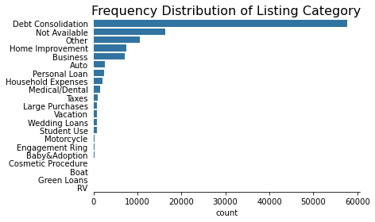

```python
hor_bar_plot()
```

From the bar plot above, the distribution of Listing category is right skewed and some of the bars are not showing becauase of the abnornammly large number of Debt consolidation loans. we have plot it on the log scale (10) to be make the bars visible.

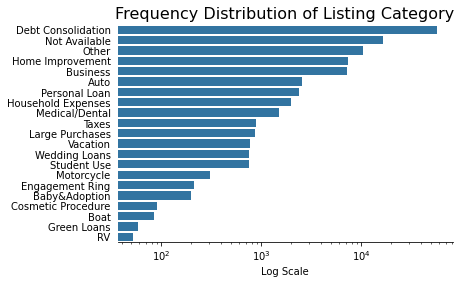

```python
#plot Listing category on the logscale
plt.xscale('log')
hor_bar_plot()
plt.xlabel('Log Scale');
```

**Observation:**

> All the bars are showing now, with the highest number of loans being Debt Consolidation and the list are RV loans.

**How is Loan Original Amount Distributed**

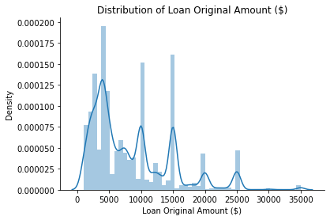

```python
sb.distplot(Df_ProperLoan_Delinquent['LoanOriginalAmount'])
plt.xlabel('Loan Original Amount ($)')
plt.title('Distribution of Loan Original Amount ($)')
sb.despine(left = False, bottom = False)
```

**Observation:**

> From the distribution plot above we observe that loan Original amount has a multimodal distribution with multiple peaks.

**How are the loans Distributed over the Years?**

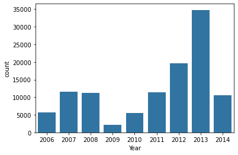

```python
# distribution of loans over the years
sb.countplot(data=Df_ProperLoan_Delinquent, x='Year', color=color_base);
```

**Observation:**

> Over the years the loans fluctuates with a dip in 2009 and an unprecidented increase in the number of applications in the year 2013.

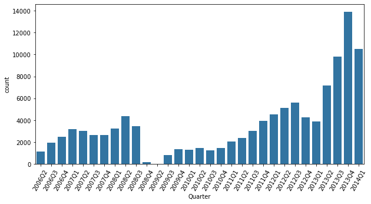

```python
# distribution of loans over the years
plt.figure(figsize=[10,5])
sb.countplot(data=Df_ProperLoan_Delinquent, x='Quarter', color=color_base)
plt.xticks(rotation=60);
```

**Observation:**

> The 4th quarter of 2013 experienced the higest number of loan applications

**Do more loan applications come from borrowers with verified Income?**

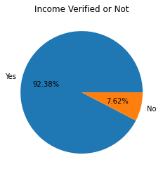

```python
#Plot a pie chart
plt.pie(Df_ProperLoan_Delinquent.IncomeVerifiable.value_counts(), labels=["Yes", "No"],colors=None,autopct='%.2f%%')
plt.title('Income Verified or Not');
```

**Observation:**

> Majority (92.38%)of the borrowers have veriable income with just a few (7.62%) without their income verified

**Is there any difference in the percentage of Borrowers who own a house and those that don't?**

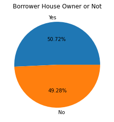

```python
#Plot a pie chart
plt.pie(Df_ProperLoan_Delinquent.IsBorrowerHomeowner.value_counts(), labels=["Yes", "No"],colors=None,autopct='%.2f%%')
plt.title('Borrower House Owner or Not');
```

**Observation:**

> There is a marginal difference between borrowers that own a home (50.72%)and borrowers who don't own a house (49.28%).

**What is the employment status of people with the higest loan applications**

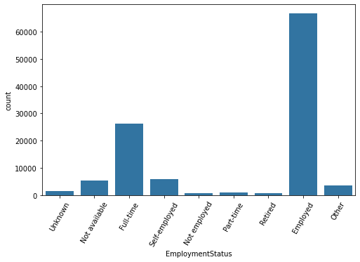

```python
# countplot of employmentstatus
plt.figure(figsize=[8,5])
sb.countplot(data=Df_ProperLoan_Delinquent, x='EmploymentStatus', color=color_base)
plt.xticks(rotation=60);
```

**Observation:**

> people who specified thier employment status as employed had the highest number of applications in the prosper loan portfolios.

### Discuss the distribution(s) of your variable(s) of interest. Were there any unusual points? Did you need to perform any transformations?

> The distribution of Monthly Loan Payment was right skewed and some of the bars are not showing becauase of the abnornammly large amount, we have to drop the outlyers and plotted values from $1000 below to make the bars visible.

## Bivariate Exploration

> In this section, investigate relationships between pairs of variables in your data. Make sure the variables that you cover here have been introduced in some fashion in the previous section (univariate exploration).

**Does BorrowerAPR has any relationship with any numeric feature selected**

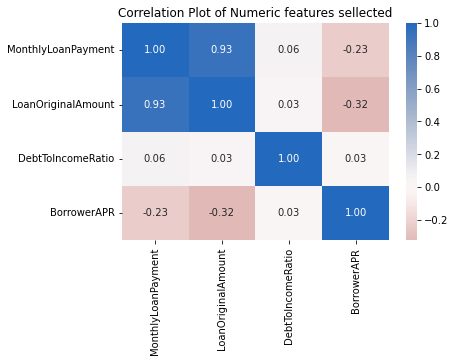

```python
num_var = ['MonthlyLoanPayment', 'LoanOriginalAmount', 'DebtToIncomeRatio','BorrowerAPR',]
sb.heatmap(Df_ProperLoan_Delinquent[num_var].corr(), annot = True, fmt = '0.2f',
          cmap = 'vlag_r', center = 0)
plt.xticks(rotation = 90)
plt.title('Correlation Plot of Numeric features sellected');
```

Yes there is a relationship. Let us visual

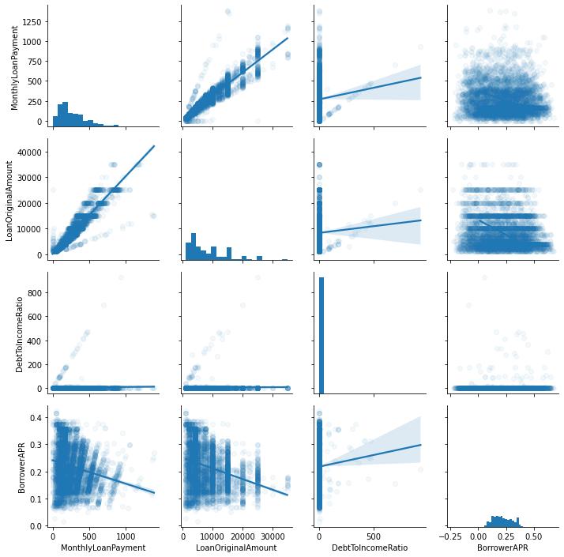

```python
# plot matrix: sample 5000 loans so that plots are clearer and render faster
loan_subsample = Df_ProperLoan_Delinquent.sample(5000)
g = sb.PairGrid(data = loan_subsample, vars = num_var)
g = g.map_diag(plt.hist, bins=20)
g.map_offdiag(sb.regplot, x_jitter=0.3, scatter_kws={'alpha':1/20});
```

**How Does Monthly Loan Pyment affect Deliquency status?**

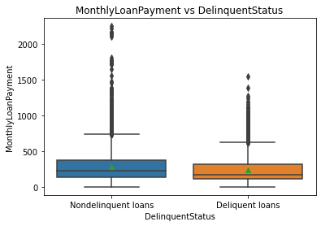

```python
#plot replot of MonthlyLoanPayment vs DelinquentStatus
sb.boxplot(data=Df_ProperLoan_Delinquent, y="MonthlyLoanPayment", x="DelinquentStatus",showmeans=True)
plt.title('MonthlyLoanPayment vs DelinquentStatus')
plt.xticks([1,0],['Deliquent loans','Nondelinquent loans']);
```

**Observation:**

> We observe that deliquent loans have lower monthly loans payment than loans that are not delinquent

**How does Credit Score affect loan delinquency**

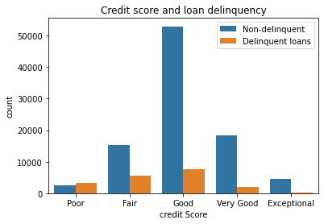

```python
#plot of Credit score vs Term
sb.countplot(data = Df_ProperLoan_Delinquent, x = 'CreditScore', hue = 'DelinquentStatus')
plt.xlabel('credit Score')
plt.title('Credit score and loan delinquency')
plt.legend(['Non-delinquent','Delinquent loans']);
```

**Observation:**

> We observe that the number of delinquent loans increase as we move from poor to fair ratings and peaked at good credit score then decrease steadily as we move up the Credit score rating scale.

[figure not shown]

```python
#violinplot of emplotment status vs borrowers rate
defaultcolor = sb.color_palette()[0]
sb.violinplot(data = Df_ProperLoan_Delinquent, x = 'DelinquentStatus', y = 'LoanOriginalAmount', color=defaultcolor);
plt.title('Delinquent Status vs Borrower\'s rate');
plt.ylabel('Borrower\'s rate');
plt.xlabel('Deliquent Status');
plt.xticks([0,1],['Delinquentloans','Non-delinquent']);
```

**what term of the loans has the higest number of deliquent loans**

```python
#filter delinquent loans
delinquent =Df_ProperLoan_Delinquent[Df_ProperLoan_Delinquent['DelinquentStatus']==1]
# Use DataFrame.pivot() to rearrange the data, to have Term on rows
loans= delinquent[['Term','ListingCategory']]
loans_counts = loans.groupby(['Term','ListingCategory']).size();
```

```python
# reset index
ct_counts = loans_counts.reset_index(name='count')
ct_counts.head(3)
```

|  | Term | ListingCategory | count |
| --- | --- | --- | --- |
| 0 | 12 | Auto | 5 |
| 1 | 12 | Business | 16 |
| 2 | 12 | Cosmetic Procedure | 1 |

```python
# Use DataFrame.pivot() to rearrange the data, to have Term  on rows
ct_counts = ct_counts.pivot(index = 'ListingCategory', columns = 'Term', values = 'count');
```

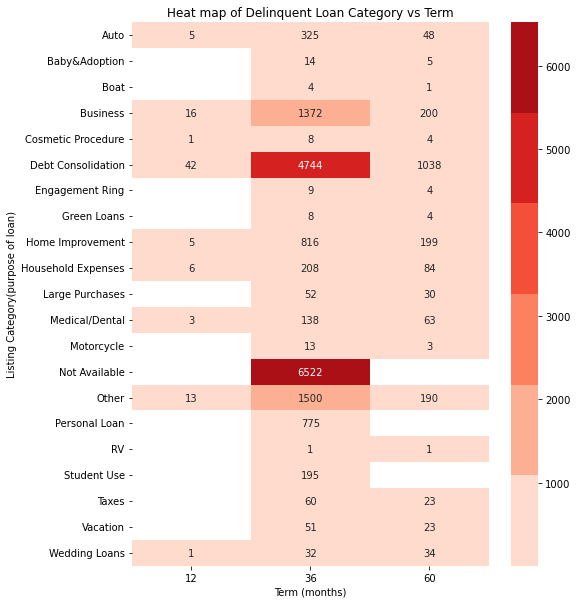

```python
#set figure size
plt.figure(figsize=[8,10])
#plot heat map
color_gred=sb.color_palette("Reds")
ax=sb.heatmap(ct_counts,cmap =color_gred ,annot = True,fmt = '.0f' )
#change label of labels
ax.set_title('Heat map of Delinquent Loan Category vs Term')
ax.set_ylabel('Listing Category(purpose of loan)')
ax.set_xlabel('Term (months)');
```

**Observation:**

> The higest number of delinquent loans are loans that do not have thier purpose specified (not available) followed by loans taken for Debt consolidation. And are all 36months term loans.

**What is the trend between monthly loan payment and loan deliquency over the years**

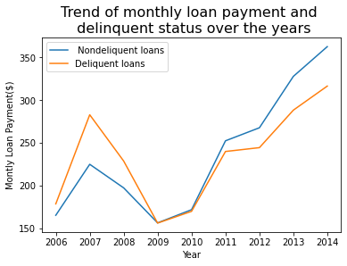

```python
# Plot of loan delinquency status over year
ax=sb.lineplot(data=Df_ProperLoan_Delinquent, x='Year', y='MonthlyLoanPayment',ci=None,hue='DelinquentStatus',legend=None )
plt.title('Trend of monthly loan payment and \n delinquent status over the years', fontsize=16)
plt.ylabel('Montly Loan Payment($)')
plt.legend([' Nondeliquent loans','Deliquent loans']);
```

### Did you observe any interesting relationships between the other features (not the main feature(s) of interest)?

> The correlation coefficient of borrower APR and loan original amount is -0.32, these shows that the two variables are negatively correlated, meaning that the more the loan amount, the lower the APR.

## Multivariate Exploration

> Here we Created plots of three or more variables to investigate our data even further.

**What is the trend of monthly loan payment and delinquent status over the years in the loan portfolio**

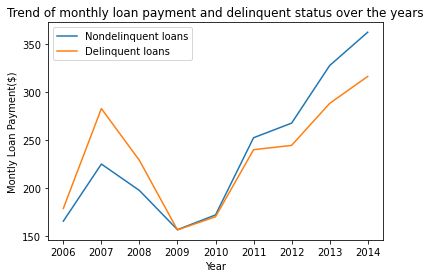

```python
# plots the pointplot for year vs BorrowerRate
sb.lineplot(data=Df_ProperLoan_Delinquent, x='Year', y='MonthlyLoanPayment',ci=None,hue='DelinquentStatus')
plt.legend(['Nondelinquent loans', 'Delinquent loans'])
plt.title('Trend of monthly loan payment and delinquent status over the years')
plt.ylabel('Montly Loan Payment($)');
```

**What term of the loans has the higest total amount of monthly loan payment deliquent and for what purpose was the loans taken**

```python
# Use DataFrame.pivot() to rearrange the data, to have Term on rows
select_var=['Term','MonthlyLoanPayment','ListingCategory']
df_loans=delinquent[select_var]

ct=df_loans.groupby(['Term','ListingCategory'], as_index=False)['MonthlyLoanPayment'].sum()
```

```python
# Use DataFrame.pivot() to rearrange the data, to have Term  on rows
ct_sums = ct.pivot( index= 'ListingCategory',columns = 'Term', values = 'MonthlyLoanPayment')
```

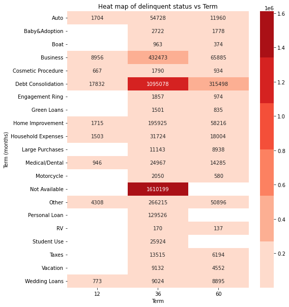

```python
#figure size
plt.figure(figsize=[8,10])
#plot heat map
color_gred=sb.color_palette("Reds")
ax=sb.heatmap(ct_sums,cmap =color_gred ,annot = True,fmt = '.0f'  )
#change label of labels

ax.set_title('Heat map of delinquent status vs Term')
ax.set_ylabel('Term (months)');
```

**Observation:**

> The higest total amount of loans delinquent was from 36 months term loans which has thier purpose specified as Not available. followed by loans taken for debts consolidation.

**How does home ownership and monthly loan payment affect loan delinquency?**

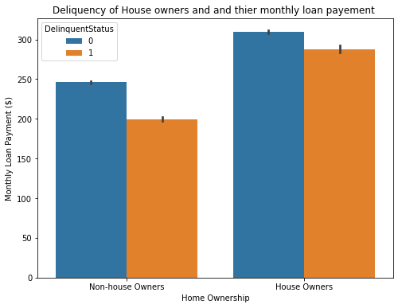

```python
# plot of deliquent status of IsBorrowerHomeownere and monthly loan payment,
plt.figure(figsize=[8,6])
sb.barplot(data = Df_ProperLoan_Delinquent, x = 'IsBorrowerHomeowner',y='MonthlyLoanPayment', hue = 'DelinquentStatus')
plt.xlabel('Home Ownership')
plt.ylabel('Monthly Loan Payment ($)')
plt.xticks([False,True],['Non-house Owners','House Owners'])
plt.title('Deliquency of House owners and and thier monthly loan payement ');
```

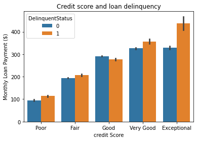

```python
# plot of deliquent status over Credit Score and monthly loan payment,
sb.barplot(data = Df_ProperLoan_Delinquent, x = 'CreditScore',y='MonthlyLoanPayment', hue = 'DelinquentStatus')
plt.xlabel('credit Score')
plt.ylabel('Monthly Loan Payment ($)')
plt.title('Credit score and loan delinquency');
```

## Conclusions

Most of my cleaning efforts where on handling missing values,removing duplicates, and ordering factors levels to make more intuitive sense in visualization.